# Bellabeat Capstone Project

zrseah

2024-03-08

## Business Task

To **analyze** the **fitness data** from **smart devices** to uncover emerging **trends** and provide **strategic recommendations**. These insights will be utilized to **enhance Bellabeat’s Application**, fostering new opportunities for **growth** and **advancement**.

## Limitations

The limitations are:

- Limited number of participants, consisting of a **small sample size** of 33 individuals
- Data that is **no longer current**. originating from the year 2016.
- **Insufficient** representation of participant **demographics**, including factors such as gender, age, lifestyle, occupation, and others.
- **Limited** variety of **physiological metrics** for tracking.

## Load Packages

```r
library ('tidyverse')
library ('dplyr')
library ('ggplot2')
library ('janitor')
library('parsedate')
library('viridis')
```

## Import Data

```r
dailyactivity <- read.csv('C:/Users/zrsea/Documents/Case Study R/Fitabase Data 4.12.16-5.12.16/dailyActivity_merged.csv')
heartrate_seconds <- read_csv('C:/Users/zrsea/Documents/Case Study R/Fitabase Data 4.12.16-5.12.16/heartrate_seconds_merged.csv')
MET_minutes <- read.csv('C:/Users/zrsea/Documents/Case Study R/Fitabase Data 4.12.16-5.12.16/minuteMETsNarrow_merged.csv')
sleepday <- read.csv('C:/Users/zrsea/Documents/Case Study R/Fitabase Data 4.12.16-5.12.16/sleepDay_merged.csv')
weightloginfo <-read.csv('C:/Users/zrsea/Documents/Case Study R/Fitabase Data 4.12.16-5.12.16/weightLogInfo_merged.csv')
```

## View first few rows of data set

```r
head(dailyactivity)
```

```
##           Id ActivityDate TotalSteps TotalDistance TrackerDistance
## 1 1503960366    4/12/2016      13162          8.50            8.50
## 2 1503960366    4/13/2016      10735          6.97            6.97
## 3 1503960366    4/14/2016      10460          6.74            6.74
## 4 1503960366    4/15/2016       9762          6.28            6.28
## 5 1503960366    4/16/2016      12669          8.16            8.16
## 6 1503960366    4/17/2016       9705          6.48            6.48
##   LoggedActivitiesDistance VeryActiveDistance ModeratelyActiveDistance
## 1                        0               1.88                     0.55
## 2                        0               1.57                     0.69
## 3                        0               2.44                     0.40
## 4                        0               2.14                     1.26
## 5                        0               2.71                     0.41
## 6                        0               3.19                     0.78
##   LightActiveDistance SedentaryActiveDistance VeryActiveMinutes
## 1                6.06                       0                25
## 2                4.71                       0                21
## 3                3.91                       0                30
## 4                2.83                       0                29
## 5                5.04                       0                36
## 6                2.51                       0                38
##   FairlyActiveMinutes LightlyActiveMinutes SedentaryMinutes Calories
## 1                  13                  328              728     1985
## 2                  19                  217              776     1797
## 3                  11                  181             1218     1776
## 4                  34                  209              726     1745
## 5                  10                  221              773     1863
## 6                  20                  164              539     1728
```

```r
head(heartrate_seconds)
```

```
## # A tibble: 6 × 3
##           Id Time                 Value
##        <dbl> <chr>                <dbl>
## 1 2022484408 4/12/2016 7:21:00 AM    97
## 2 2022484408 4/12/2016 7:21:05 AM   102
## 3 2022484408 4/12/2016 7:21:10 AM   105
## 4 2022484408 4/12/2016 7:21:20 AM   103
## 5 2022484408 4/12/2016 7:21:25 AM   101
## 6 2022484408 4/12/2016 7:22:05 AM    95
```

```r
head(MET_minutes)
```

```
##           Id        ActivityMinute METs
## 1 1503960366 4/12/2016 12:00:00 AM   10
## 2 1503960366 4/12/2016 12:01:00 AM   10
## 3 1503960366 4/12/2016 12:02:00 AM   10
## 4 1503960366 4/12/2016 12:03:00 AM   10
## 5 1503960366 4/12/2016 12:04:00 AM   10
## 6 1503960366 4/12/2016 12:05:00 AM   12
```

```r
head(sleepday)
```

```
##           Id              SleepDay TotalSleepRecords TotalMinutesAsleep
## 1 1503960366 4/12/2016 12:00:00 AM                 1                327
## 2 1503960366 4/13/2016 12:00:00 AM                 2                384
## 3 1503960366 4/15/2016 12:00:00 AM                 1                412
## 4 1503960366 4/16/2016 12:00:00 AM                 2                340
## 5 1503960366 4/17/2016 12:00:00 AM                 1                700
## 6 1503960366 4/19/2016 12:00:00 AM                 1                304
##   TotalTimeInBed
## 1            346
## 2            407
## 3            442
## 4            367
## 5            712
## 6            320
```

```r
head(weightloginfo)
```

```
##           Id                  Date WeightKg WeightPounds Fat   BMI
## 1 1503960366  5/2/2016 11:59:59 PM     52.6     115.9631  22 22.65
## 2 1503960366  5/3/2016 11:59:59 PM     52.6     115.9631  NA 22.65
## 3 1927972279  4/13/2016 1:08:52 AM    133.5     294.3171  NA 47.54
## 4 2873212765 4/21/2016 11:59:59 PM     56.7     125.0021  NA 21.45
## 5 2873212765 5/12/2016 11:59:59 PM     57.3     126.3249  NA 21.69
## 6 4319703577 4/17/2016 11:59:59 PM     72.4     159.6147  25 27.45
##   IsManualReport        LogId
## 1           True 1.462234e+12
## 2           True 1.462320e+12
## 3          False 1.460510e+12
## 4           True 1.461283e+12
## 5           True 1.463098e+12
## 6           True 1.460938e+12
```

## View data type

```r
str(dailyactivity)
```

```
## 'data.frame':    940 obs. of  15 variables:
##  $ Id                      : num  1.5e+09 1.5e+09 1.5e+09 1.5e+09 1.5e+09 ...
##  $ ActivityDate            : chr  "4/12/2016" "4/13/2016" "4/14/2016" "4/15/2016" ...
##  $ TotalSteps              : int  13162 10735 10460 9762 12669 9705 13019 15506 10544 9819 ...
##  $ TotalDistance           : num  8.5 6.97 6.74 6.28 8.16 ...
##  $ TrackerDistance         : num  8.5 6.97 6.74 6.28 8.16 ...
##  $ LoggedActivitiesDistance: num  0 0 0 0 0 0 0 0 0 0 ...
##  $ VeryActiveDistance      : num  1.88 1.57 2.44 2.14 2.71 ...
##  $ ModeratelyActiveDistance: num  0.55 0.69 0.4 1.26 0.41 ...
##  $ LightActiveDistance     : num  6.06 4.71 3.91 2.83 5.04 ...
##  $ SedentaryActiveDistance : num  0 0 0 0 0 0 0 0 0 0 ...
##  $ VeryActiveMinutes       : int  25 21 30 29 36 38 42 50 28 19 ...
##  $ FairlyActiveMinutes     : int  13 19 11 34 10 20 16 31 12 8 ...
##  $ LightlyActiveMinutes    : int  328 217 181 209 221 164 233 264 205 211 ...
##  $ SedentaryMinutes        : int  728 776 1218 726 773 539 1149 775 818 838 ...
##  $ Calories                : int  1985 1797 1776 1745 1863 1728 1921 2035 1786 1775 ...
```

```r
str(heartrate_seconds)
```

```
## spc_tbl_ [2,483,658 × 3] (S3: spec_tbl_df/tbl_df/tbl/data.frame)
##  $ Id   : num [1:2483658] 2.02e+09 2.02e+09 2.02e+09 2.02e+09 2.02e+09 ...
##  $ Time : chr [1:2483658] "4/12/2016 7:21:00 AM" "4/12/2016 7:21:05 AM" "4/12/2016 7:21:10 AM" "4/12/2016 7:21:20 AM" ...
##  $ Value: num [1:2483658] 97 102 105 103 101 95 91 93 94 93 ...
##  - attr(*, "spec")=
##   .. cols(
##   ..   Id = col_double(),
##   ..   Time = col_character(),
##   ..   Value = col_double()
##   .. )
##  - attr(*, "problems")=<externalptr>
```

```r
str(MET_minutes)
```

```
## 'data.frame':    1325580 obs. of  3 variables:
##  $ Id            : num  1.5e+09 1.5e+09 1.5e+09 1.5e+09 1.5e+09 ...
##  $ ActivityMinute: chr  "4/12/2016 12:00:00 AM" "4/12/2016 12:01:00 AM" "4/12/2016 12:02:00 AM" "4/12/2016 12:03:00 AM" ...
##  $ METs          : int  10 10 10 10 10 12 12 12 12 12 ...
```

```r
str(sleepday)
```

```
## 'data.frame':    413 obs. of  5 variables:
##  $ Id                : num  1.5e+09 1.5e+09 1.5e+09 1.5e+09 1.5e+09 ...
##  $ SleepDay          : chr  "4/12/2016 12:00:00 AM" "4/13/2016 12:00:00 AM" "4/15/2016 12:00:00 AM" "4/16/2016 12:00:00 AM" ...
##  $ TotalSleepRecords : int  1 2 1 2 1 1 1 1 1 1 ...
##  $ TotalMinutesAsleep: int  327 384 412 340 700 304 360 325 361 430 ...
##  $ TotalTimeInBed    : int  346 407 442 367 712 320 377 364 384 449 ...
```

```r
str(weightloginfo)
```

```
## 'data.frame':    67 obs. of  8 variables:
##  $ Id            : num  1.50e+09 1.50e+09 1.93e+09 2.87e+09 2.87e+09 ...
##  $ Date          : chr  "5/2/2016 11:59:59 PM" "5/3/2016 11:59:59 PM" "4/13/2016 1:08:52 AM" "4/21/2016 11:59:59 PM" ...
##  $ WeightKg      : num  52.6 52.6 133.5 56.7 57.3 ...
##  $ WeightPounds  : num  116 116 294 125 126 ...
##  $ Fat           : int  22 NA NA NA NA 25 NA NA NA NA ...
##  $ BMI           : num  22.6 22.6 47.5 21.5 21.7 ...
##  $ IsManualReport: chr  "True" "True" "False" "True" ...
##  $ LogId         : num  1.46e+12 1.46e+12 1.46e+12 1.46e+12 1.46e+12 ...
```

## Description of Data Source

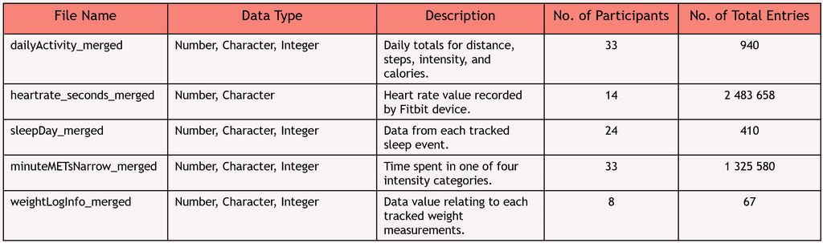

## Clean column names

```r
dailyactivity <- clean_names(dailyactivity)
heartrate_seconds <- clean_names(heartrate_seconds)
MET_minutes <- clean_names(MET_minutes)
sleepday <- clean_names(sleepday)
weightloginfo <- clean_names(weightloginfo)
```

## Amend data type: Standardize date/time column

### Daily Activity

```r
# remove unnecessary spacing in column
dailyactivity$activity_date <- trimws(dailyactivity$activity_date)
# Convert the activity_date column to character
dailyactivity$activity_date <- as.character(dailyactivity$activity_date)
# Convert the character dates to Date objects with the specified format
dailyactivity$activity_date <- as.Date(dailyactivity$activity_date, format = '%m/%d/%Y')
# Format the Date objects to the desired format ("%d/%m/%Y")
dailyactivity$activity_date <- format(dailyactivity$activity_date, '%d/%m/%Y')
```

### Heartrate

```r
# Remove unnecessary spacing in column
heartrate_seconds$time <- trimws(heartrate_seconds$time)
# Define a function to parse dates
parse_date <- function(date) {
  if (grepl("AM|PM", date)) {
    as.POSIXct(date, format = "%m/%d/%Y %I:%M:%S %p")
  } else {
    as.POSIXct(date, format = "%m/%d/%Y %H:%M" )
  }
}
# Apply parse dates to time column
heartrate_seconds$time <- lapply(heartrate_seconds$time, parse_date)
# Format the date_time objects
heartrate_seconds$time <- lapply(heartrate_seconds$time, function(x) format(x, "%d/%m/%Y %H:%M"))
```

### MET

```r
# Remove unnecessary spacing in column
MET_minutes$activity_minute <- trimws(MET_minutes$activity_minute)
# Define a function to parse dates
parse_date <- function(date) {
  if (grepl("AM|PM", date)) {
    as.POSIXct(date, format = "%m/%d/%Y %I:%M:%S %p")
  } else {
    as.POSIXct(date, format = "%m/%d/%Y %H:%M" )
  }
}
# Apply parsed dates to activity minutes column
MET_minutes$activity_minute <- lapply(MET_minutes$activity_minute, parse_date)
# Format date_time objects
MET_minutes$activity_minute <- lapply(MET_minutes$activity_minute, function(x) format(x, "%d/%m/%Y %H:%M"))
```

### Sleep

```r
# Remove unnecessary spacing in column
sleepday$sleep_day <- trimws(sleepday$sleep_day)
# Define a function to parse dates
parse_date <- function(date) {
  if (grepl("AM|PM", date)) {
    as.POSIXct(date, format = "%m/%d/%Y %I:%M:%S %p")
  } else {
    as.POSIXct(date, format = "%m/%d/%Y %H:%M")
  }
}
# Apply parse date to sleep_day column
sleepday$sleep_day <- lapply(sleepday$sleep_day, parse_date)
# Format date_time objects
sleepday$sleep_day <- lapply(sleepday$sleep_day, function(x) format (x, "%d/%m/%Y %H:%M"))
```

### Weightloginfo

```r
# Remove unnecessary spacing in column
weightloginfo$date <- trimws(weightloginfo$date)
# Define parse date function
parse_date <- function(date) {
  if (grepl("AM|PM", date)) {
    as.POSIXct(date, format = "%m/%d/%Y %I:%M:%S %p")
  } else {
    as.POSIXct(date, format = "%m/%d/%Y %H:%M")
  }
}
# Apply parse_date to date column
weightloginfo$date <- lapply(weightloginfo$date, parse_date)
# Format date-time object
weightloginfo$date <- lapply(weightloginfo$date, function(x) format(x, "%d/%m/%Y %H:%M"))
```

## Check for duplicates

```r
sum(duplicated(dailyactivity))
```

```
## [1] 0
```

```r
sum(duplicated(MET_minutes))
```

```
## [1] 0
```

```r
sum(duplicated(sleepday))
```

```
## [1] 3
```

```r
sum(duplicated(weightloginfo))
```

```
## [1] 0
```

## Remove duplicates

```r
sleepday <- unique(sleepday)
```

## Check for empty or NA rows or columns

```r
sum(is.na(dailyactivity))
```

```
## [1] 0
```

```r
sum(is.na(heartrate_seconds))
```

```
## [1] 0
```

```r
sum(is.na(MET_minutes))
```

```
## [1] 0
```

```r
sum(is.na(sleepday))
```

```
## [1] 0
```

```r
sum(is.na(weightloginfo))
```

```
## [1] 65
```

## Remove NA columns or rows

```r
weightloginfo <- select(weightloginfo, -5)
```

## Number of participants for each category

```r
n_distinct(dailyactivity$id)
```

```
## [1] 33
```

```r
n_distinct(heartrate_seconds$id)
```

```
## [1] 14
```

```r
n_distinct(MET_minutes$id)
```

```
## [1] 33
```

```r
n_distinct(sleepday$id)
```

```
## [1] 24
```

```r
n_distinct(weightloginfo$id)
```

```
## [1] 8
```

## Analysis

### Breakdown of number of participants for each category

```r
Participation_Rate <- tibble(
  Unique_Daily_Activity_Users = n_distinct(dailyactivity$id),
  Unique_Heartrate_Users = n_distinct(heartrate_seconds$id),
  Unique_MET_Users = n_distinct(MET_minutes$id),
  Unique_Sleep_Tracking_Users = n_distinct(sleepday$id),
  Unique_Weight_Log_Info_Users = n_distinct(weightloginfo$id)
)
Participation_Rate <- t(Participation_Rate)
colnames(Participation_Rate) <- c("Count")

Participation_Rate
```

```
##                              Count
## Unique_Daily_Activity_Users     33
## Unique_Heartrate_Users          14
## Unique_MET_Users                33
## Unique_Sleep_Tracking_Users     24
## Unique_Weight_Log_Info_Users     8
```

### Daily Activity Tracking

Daily Activity recorded active minutes, active distances traveled, total steps taken, total distance traveled and calories burned.

#### Averages of different activities of each participants

```
## # A tibble: 33 × 13
##            ID Number_of_Entries Average_Total_Steps Average_Total_Distance
##         <dbl>             <int>               <dbl>                  <dbl>
##  1 1503960366                31               12117                   7.81
##  2 1624580081                31                5744                   3.91
##  3 1644430081                30                7283                   5.3
##  4 1844505072                31                2580                   1.71
##  5 1927972279                31                 916                   0.63
##  6 2022484408                31               11371                   8.08
##  7 2026352035                31                5567                   3.45
##  8 2320127002                31                4717                   3.19
##  9 2347167796                18                9520                   6.36
## 10 2873212765                31                7556                   5.1
## # ℹ 23 more rows
## # ℹ 9 more variables: Average_Very_Active_Distance <dbl>,
## #   Average_Moderately_Active_Distance <dbl>,
## #   Average_Light_Active_Distance <dbl>, Average_Sedentary_Distance <dbl>,
## #   Average_Very_Active_Mins <dbl>, Average_Fairly_Active_Mins <dbl>,
## #   Average_Lightly_Active_Mins <dbl>, Average_Sedentary_Mins <dbl>,
## #   Average_Calories_Count <dbl>
```

There is a 100% participation rate for this category with more than half of the participants with daily entries.

#### Summary of Daily Activity data

```
##                                       Min. 1st Qu.  Median    Mean 3rd Qu.
## Average_Total_Steps                 916.00 5567.00 7283.00 7519.39 9520.00
## Average_Total_Distance                0.63    3.45    5.30    5.40    6.91
## Average_Very_Active_Distance          0.01    0.14    0.73    1.45    2.21
## Average_Moderately_Active_Distance    0.01    0.13    0.50    0.56    0.77
## Average_Light_Active_Distance         0.51    2.61    3.50    3.32    4.14
## Average_Sedentary_Distance            0.00    0.00    0.00    0.00    0.00
## Average_Very_Active_Mins              0.10    3.58   10.39   20.31   23.42
## Average_Fairly_Active_Mins            0.26    4.03   12.32   13.26   19.35
## Average_Lightly_Active_Mins          38.58  143.84  206.19  191.52  245.81
## Average_Sedentary_Mins              662.32  766.42 1077.55  999.15 1206.61
## Average_Calories_Count             1483.35 1916.97 2131.77 2282.44 2599.62
##                                        Max.
## Average_Total_Steps                16040.00
## Average_Total_Distance                13.21
## Average_Very_Active_Distance           8.51
## Average_Moderately_Active_Distance     2.75
## Average_Light_Active_Distance          6.19
## Average_Sedentary_Distance             0.01
## Average_Very_Active_Mins              87.33
## Average_Fairly_Active_Mins            61.27
## Average_Lightly_Active_Mins          327.90
## Average_Sedentary_Mins              1317.42
## Average_Calories_Count              3436.58
```

#### Active distances and minutes

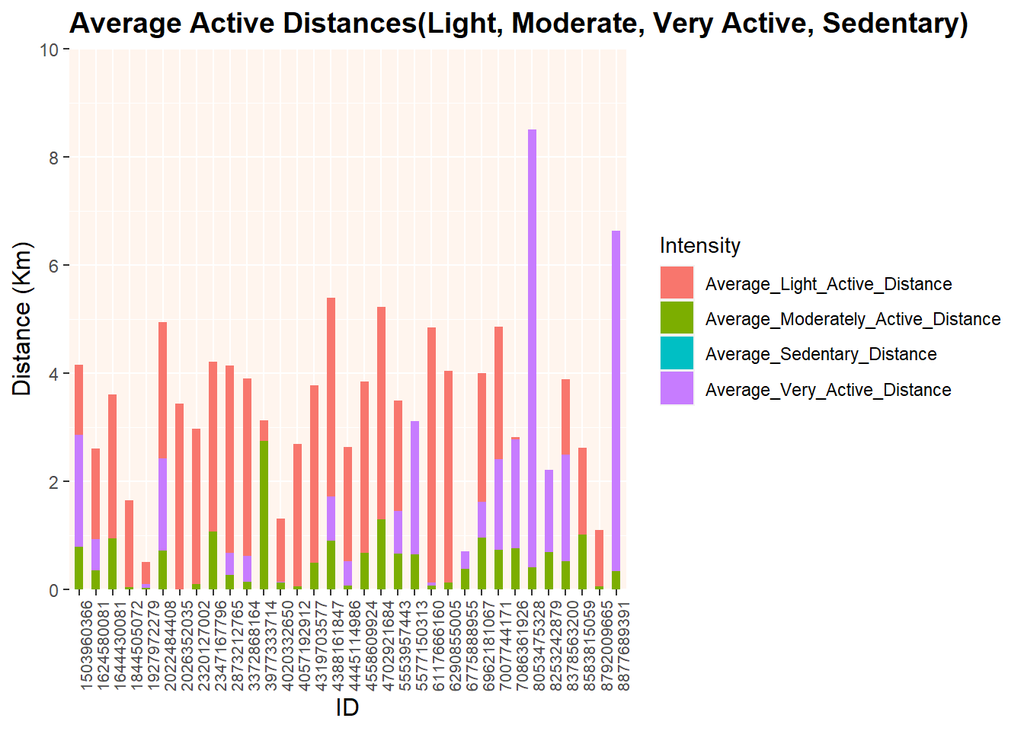

Based on the chart depicted, **most** of the participants primarily participated in **lightly active pursuits**, except for a **minority** who were notably involved in **highly active endeavors**.

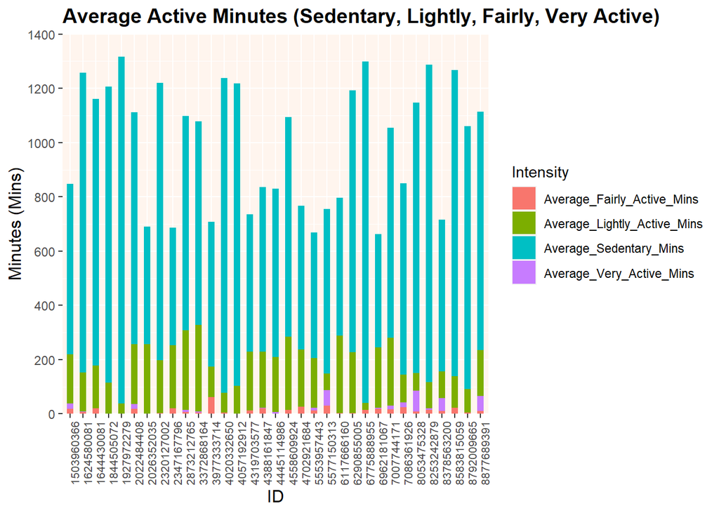

Participants were generally engaged in a **sedentary** lifestyle of **sitting** or **laying down** with **little** to **no exercise**.

#### Relationship between average calories burned, average total steps taken and average total distance traveled

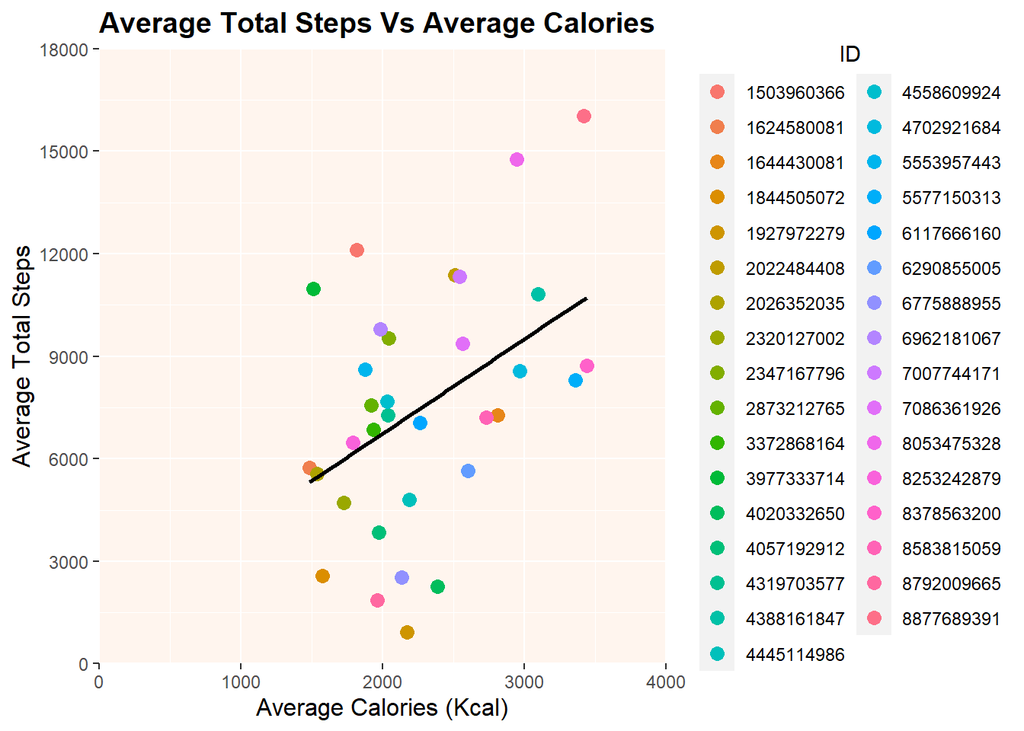

Average calories burned and average total steps taken form a positive relationship in which, the greater the number of steps taken, the greater the amount of calories burned.

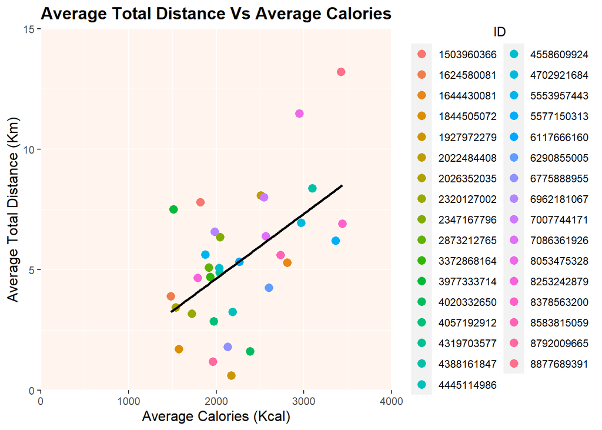

Average calories burned and average total distance traveled form a positive relationship. The greater the distance traveled, the greater the amount of calories burned.

### Heart Rate Tracking

Only **42 %** of the participants made use of the Fitbeat to keep track of their heart rates.

#### Average Heart Rate per minute of each participant

```
## # A tibble: 14 × 3
##            ID Number_of_Entries Average_BPM
##         <dbl>             <int>       <dbl>
##  1 2022484408            154104          80
##  2 2026352035              2490          94
##  3 2347167796            152683          77
##  4 4020332650            285461          82
##  5 4388161847            249748          66
##  6 4558609924            192168          82
##  7 5553957443            255174          69
##  8 5577150313            248560          70
##  9 6117666160            158899          84
## 10 6775888955             32771          92
## 11 6962181067            266326          78
## 12 7007744171            133592          91
## 13 8792009665            122841          72
## 14 8877689391            228841          84
```

#### Summary of Heart Rate data

```
##             Min. 1st Qu. Median  Mean 3rd Qu. Max.
## Average_BPM   66   73.25     81 80.07      84   94
```

#### Heart Rate per minute

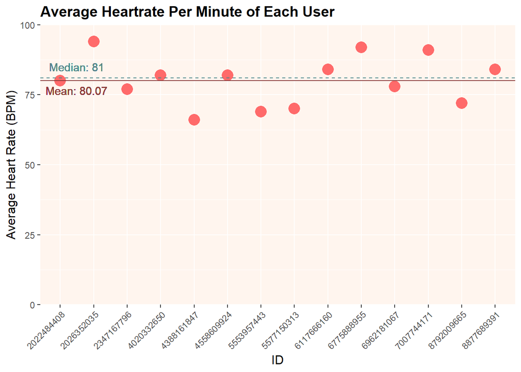

The average Heart Rate per minute of participants ranges from **66 BPM to 94 BPM**. The median heart rate is **81 BPM** while the mean heart rate is **80.07 BPM**. Participants’ heart rate are generally within the healthy range.

### MET Tracking

**All** participants made use of their Fitbits to track their METs. Majority of the participants tracked their MET values on a near-daily basis.

#### Average MET of each participant

```
## # A tibble: 33 × 3
##            ID Number_of_Entries Average_MET
##         <dbl>             <int>       <dbl>
##  1 1503960366             43020         1.7
##  2 1624580081             44160         1.3
##  3 1644430081             42480         1.4
##  4 1844505072             43860         1.2
##  5 1927972279             44160         1.1
##  6 2022484408             44100         1.7
##  7 2026352035             44160         1.4
##  8 2320127002             44100         1.3
##  9 2347167796             24840         1.6
## 10 2873212765             44160         1.5
## # ℹ 23 more rows
```

#### Summary of MET Data

```
##             Min. 1st Qu. Median Mean 3rd Qu. Max.
## Average_MET  1.1     1.3    1.5  1.5     1.6    2
```

#### MET values

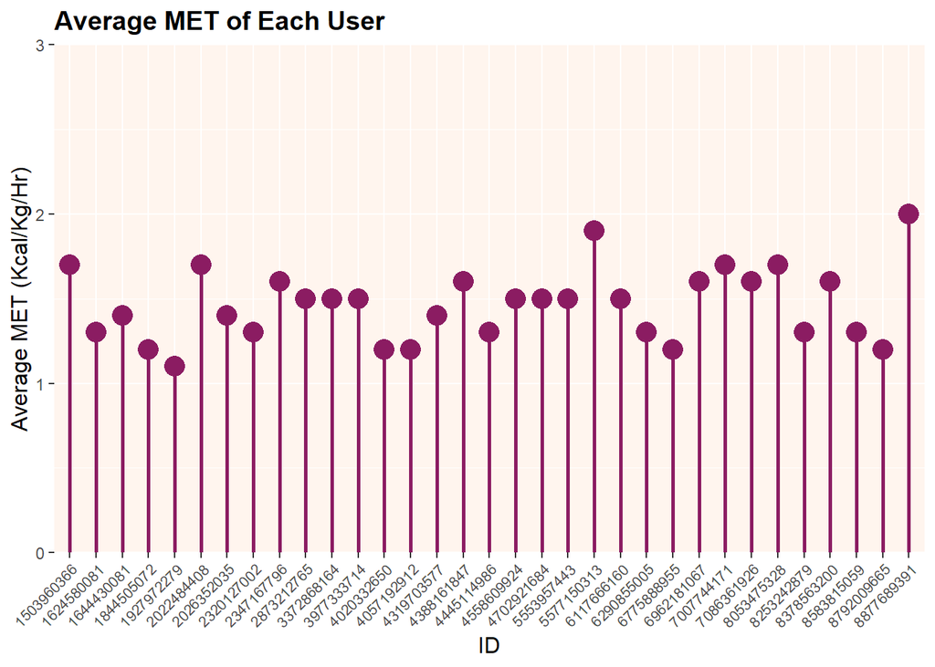

The MET values activities the participants range from **1.1 Kcal/Kg/Hr** to **2 Kcal/kg/Hr**. Participants were mostly engaged in **light intensity acitvities**. This observation is additionally supported by the graph below, which illustrates the **frequency** of **light intensity activities** compared to activities of **other intensities**.

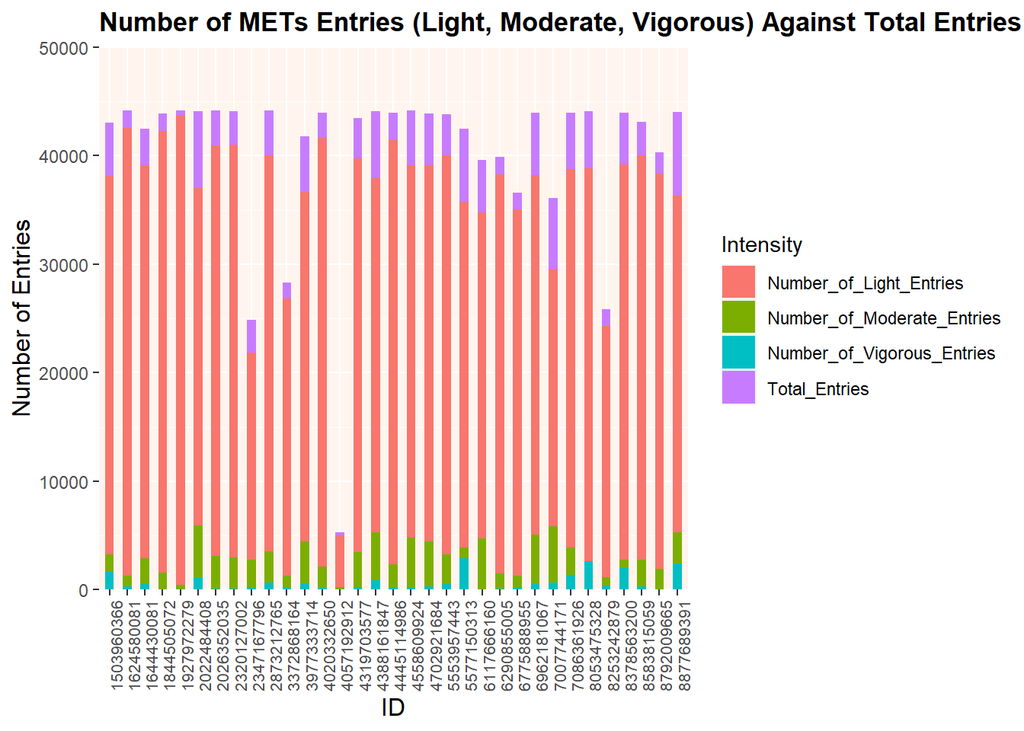

### Sleep Tracking

**24** of 33 Participant used Fitbit to track their sleeping habits.

#### Average duration of sleep, bed and idle time of each participant

```
## # A tibble: 24 × 5
##            ID Number_of_Entries Average_Sleep_Time Average_Bed_Time
##         <dbl>             <int>              <dbl>            <dbl>
##  1 1503960366                25               6                6.39
##  2 1644430081                 4               4.9              5.77
##  3 1844505072                 3              10.9             16.0
##  4 1927972279                 5               6.95             7.3
##  5 2026352035                28               8.44             8.96
##  6 2320127002                 1               1.02             1.15
##  7 2347167796                15               7.45             8.19
##  8 3977333714                28               4.89             7.69
##  9 4020332650                 8               5.82             6.33
## 10 4319703577                26               7.94             8.37
## # ℹ 14 more rows
## # ℹ 1 more variable: Average_Idle_Time <dbl>
```

#### Summary of Sleep Tracking Data

```
##                    Min. 1st Qu. Median Mean 3rd Qu.  Max.
## Average_Sleep_Time 1.02    5.60   6.96 6.29    7.49 10.87
## Average_Bed_Time   1.15    6.28   7.43 7.00    8.12 16.02
## Average_Idle_Time  0.05    0.30   0.41 0.71    0.57  5.15
```

#### Sleep Tracking hours

[figure not shown]

### Weight and BMI

There is minimal participation of **8/33** participants in this category.

#### Average BMI and Weight and of each participant

```
## # A tibble: 8 × 6
##           ID Number_of_Entries Average_Weight_Kg Average_BMI Weight_Status
##        <dbl>             <int>             <dbl>       <dbl> <chr>
## 1 1503960366                 2              52.6        22.6 Healthy
## 2 1927972279                 1             134.         47.5 Obese
## 3 2873212765                 2              57          21.6 Healthy
## 4 4319703577                 2              72.4        27.4 Overweight
## 5 4558609924                 5              69.6        27.2 Overweight
## 6 5577150313                 1              90.7        28   Overweight
## 7 6962181067                30              61.6        24.0 Healthy
## 8 8877689391                24              85.2        25.5 Overweight
## # ℹ 1 more variable: Manual_Input <chr>
```

#### Distribution of BMI weight status

```
##                           Count
## Count_of_Manual_Input         5
## Count_of_Non_Manual_Input     3
## Count_of_Underweight          0
## Count_of_Healthy              3
## Count_of_Overweight           4
## Count_of_Obese                1
```

More than half of the participants fall are categorised as having an unhealthy BMI.

#### Summary of Weight and BMI Data

```
##                    Min. 1st Qu. Median  Mean 3rd Qu.   Max.
## Average_Weight_Kg 52.60   60.41  71.00 77.81   86.54 133.50
## Average_BMI       21.57   23.69  26.35 27.99   27.56  47.54
```

#### Weight

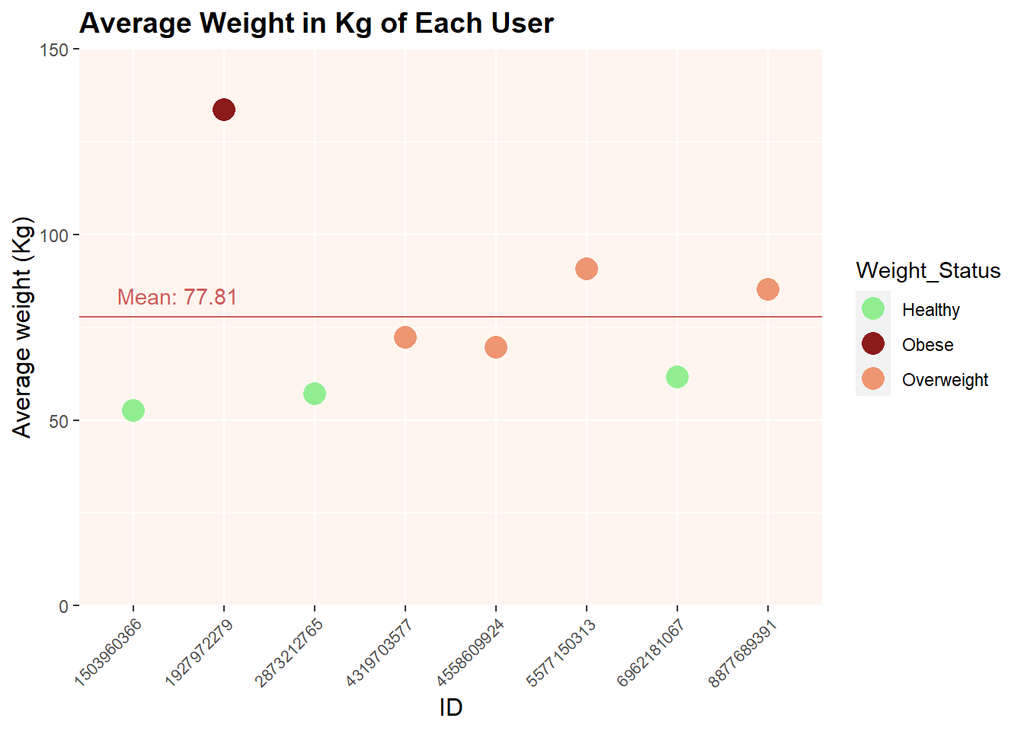

#### BMI

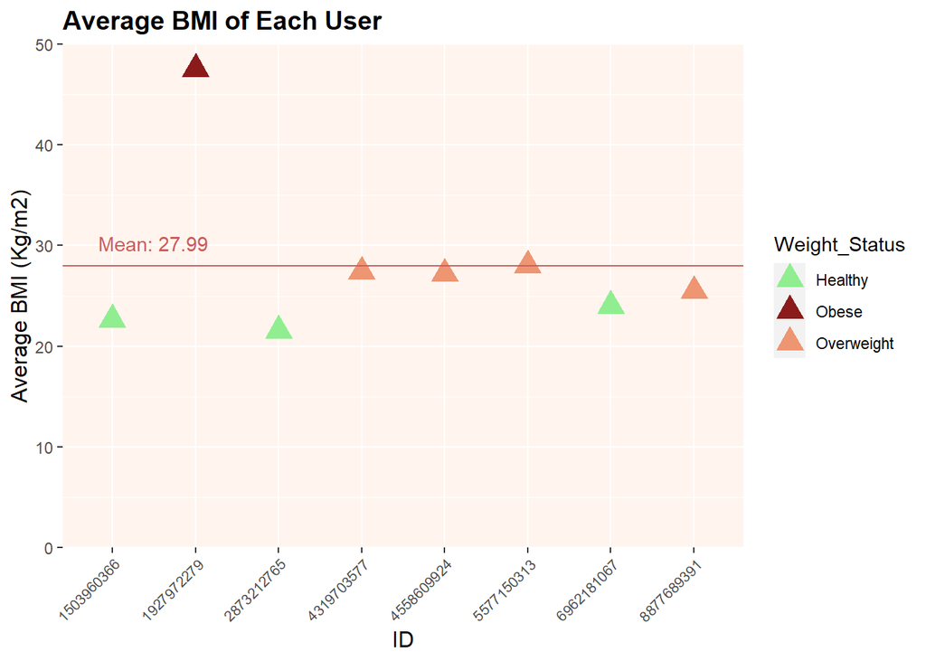

The average BMI of each participant ranges from **21.57 Kg/m2 to 47.54 Kg/m2**. The mean BMI is **27.99 Kg/m2**.

## Key Findings

Trends:

- **Positive** relationship between **calories burned** and **steps/distances traveled**.

Participants’ health and lifestyle:

- Participants commonly experienced **insufficient sleep**.
- Participants with recorded heart rate typically exhibit indicators of a **healthy heart**.
- Participants predominantly partake in **light-intensity** activities.
- Participants spent a significant portion of their days in **sedentary state**.
- Among those with recorded weight and BMI, over half demonstrate an **unhealthy BMI**.

## Recommendations

- Conduct a **follow-up survey** to research on the factors behind participants’ under utilization of Fitbit for monitoring heart rate, BMI and weight.
- Enhance **in-app functionalitists** for **personalization** and **interactivity**.
- Encourage participants to increase their engagement in **higher-intensity activities** by establishing **challenges** within the application.
- Customize a **limited-access workout regimen tailored** to each user within the application. (Upgrade to premium membership for complete access.)

## Credits

[Data source](https://www.kaggle.com/datasets/arashnic/fitbit)